# IODS course project

# Exercise 3

```r
setwd("C:/Users/rekar/Documents/Road to PhD/Kurssit/Open data science/IODS-project/data")
pormath <- read.csv("pormath.csv")

library(dplyr)
library(tidyverse)
library(GGally)
library(viridis)
library(sjPlot)
library(cowplot)
```

## Data at hand

In this Exercise, the data assessed is retrieved from the Machine Learning Repository, collected by Paolo Cortez. It comprises of two data sets of Secondary school students from Portuguese schools. The data comprises of both school reports and questionnaires. More information about the data set used in this exercise can be found [here](https://archive.ics.uci.edu/ml/datasets/Student+Performance). The two separate data sets are about performance in maths and Portuguese, respectively. Only the participants who were in the both data sets, are included in the combined data used in this exercise and others excluded. Hereby, the total N of observations is 370.

```r
colnames(pormath)
```

```
##  [1] "school"     "sex"        "age"        "address"    "famsize"
##  [6] "Pstatus"    "Medu"       "Fedu"       "Mjob"       "Fjob"
## [11] "reason"     "guardian"   "traveltime" "studytime"  "schoolsup"
## [16] "famsup"     "activities" "nursery"    "higher"     "internet"
## [21] "romantic"   "famrel"     "freetime"   "goout"      "Dalc"
## [26] "Walc"       "health"     "n"          "id.p"       "id.m"
## [31] "failures"   "paid"       "absences"   "G1"         "G2"
## [36] "G3"         "failures.p" "paid.p"     "absences.p" "G1.p"
## [41] "G2.p"       "G3.p"       "failures.m" "paid.m"     "absences.m"
## [46] "G1.m"       "G2.m"       "G3.m"       "alc_use"    "high_use"
## [51] "cid"
```

## Choosing four variables of interest and assessing their association to high consumption of alcohol

The association of the following variables to high alcohol consumption will be assessed. High alcohol consumption here is defined as > 2, which is computed from alcohol consumption during weekdays summed with alcohol consumption during weekends (very low=1, to very high=5) divided by two.

In the following arguments for choosing these variables, I won’t be citing any research, since it is out of the scope of the current exercise. However, for presenting working hypotheses, I shortly argue why I except certain outcomes. Furthermore, I have not familiarised myself with the socio-cultural nor with the contextual factors that should be taken into account when assessing the following factors.

First, parental cohabitation (*Pstatus*) is an interesting variable, since co-parenting is often associated with better all-round well-being in children and adolescents. I expect cohabiting parenthood being associated with lower levels of alcohol consumption. Second, I find interesting to assess if attending to *nursery* has an association with alcohol consumption. As I am not familiar with the system regarding nurseries in Portugal, I can only take a wild guess, and except that those who attended nursery school (i.e., pre-school) have been more prepared to start primary school, and therefore experienced less hardships related to the very start of their educational path. Third, I assess the association of number of past class *failures* with high alcohol consumption. I assume that some adolescents not having resources (social or emotional/instrumental) to cope with failures, may build self-handicapping strategies, which then may turn into a vicious cycle; hence the higher the amount of failures, the higher the probability of high alcohol consumption. Finally, I except the perceived familial relations (*famrel*) having also an association with the alcohol consumption outcome: the higher the familial relations, the lower the probability of high alcohol consumption.

## Graphical and X-tabs examination of associations of selected variables to alcohol consumption

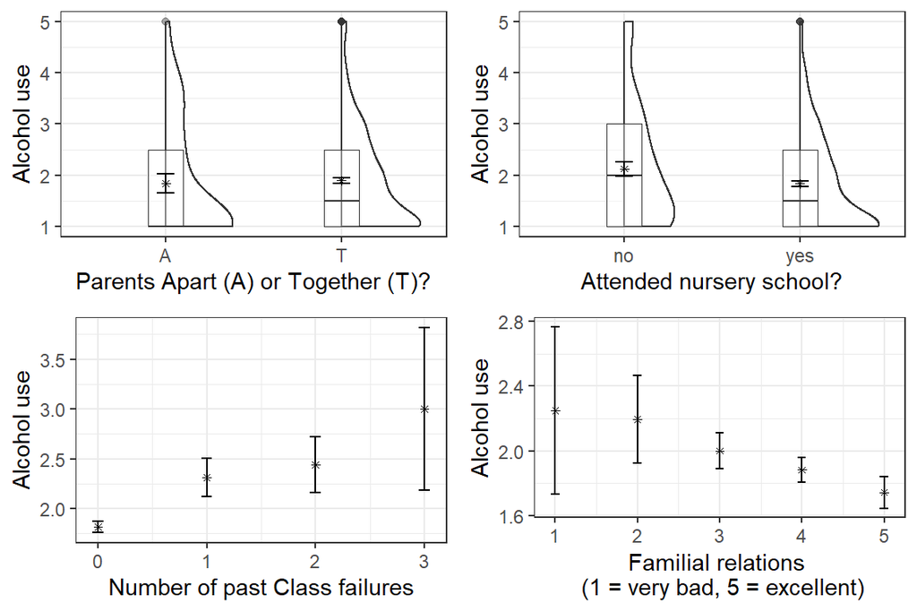

```r
###Select the variables to a new DF####
pormath_s <- pormath %>%
  select(Pstatus, nursery, failures, famrel, sex, age, high_use)

### Change logical high_use to numerical ####
#pormath_s$high_use <- as.numeric(pormath_s$high_use) # 1 = True, 0 = False

### Distributions with the discrete variable (alc_use) ####
p1 <- (pormath %>%
  ggplot(aes(Pstatus, alc_use)) +
  see::geom_violinhalf() +
    geom_boxplot(width=0.2, size=0.2, alpha=0.4) +
    stat_summary(fun=mean, geom="point", size=1, color="black", shape=8) +
    stat_summary(fun.data = mean_se, geom = "errorbar", width=0.1, size=0.5) +
  theme_bw() +
  ylab("Alcohol use") +
  xlab("Parents Apart (A) or Together (T)?")
  )

p2 <- (pormath %>%
  ggplot(aes(nursery, alc_use)) +
  see::geom_violinhalf() +
    geom_boxplot(width=0.2, size=0.2, alpha=0.4) +
    stat_summary(fun=mean, geom="point", size=1, color="black", shape=8) +
    stat_summary(fun.data = mean_se, geom = "errorbar", width=0.1, size=0.5) +
  theme_bw() +
  ylab("Alcohol use") +
  xlab("Attended nursery school?")
)

p3 <- (pormath %>%
  ggplot(aes(failures, alc_use, color=alc_use)) +
    stat_summary(fun=mean, geom="point", size=1, color="black", shape=8) +
    stat_summary(fun.data = mean_se, geom = "errorbar", width=0.1, size=0.5) +
  theme_bw() +
  ylab("Alcohol use") +
  xlab("Number of past Class failures")
)


p4 <- (pormath %>%
  ggplot(aes(famrel, alc_use)) +
    stat_summary(fun=mean, geom="point", size=1, color="black", shape=8) +
    stat_summary(fun.data = mean_se, geom = "errorbar", width=0.1, size=0.5) +
  theme_bw() +
  ylab("Alcohol use") +
  xlab("Familial relations \n (1 = very bad, 5 = excellent)")
)

plot_grid(p1, p2, p3, p4)
```

```r
### Cross-tabulations ####


tab_xtab(var.row = pormath_s$Pstatus, var.col = pormath_s$high_use, title = "Parents Cohabiting?", show.row.prc = TRUE)
```

Parents Cohabiting?

| Pstatus | high_use |  | Total |  |
| --- | --- | --- | --- | --- |
|  | FALSE | TRUE |  |  |
| A | 26 68.4 % | 12 31.6 % |  | 38 100 % |
| T | 233 70.2 % | 99 29.8 % | 332 100 % |  |
| Total | 259 70 % | 111 30 % | 370 100 % |  |

```r
tab_xtab(var.row = pormath_s$nursery, var.col = pormath_s$high_use, title = "Attended to Nursery School?", show.row.prc = TRUE)
```

Attended to Nursery School?

| nursery | high_use |  | Total |  |
| --- | --- | --- | --- | --- |
|  | FALSE | TRUE |  |  |
| no | 46 63.9 % | 26 36.1 % |  | 72 100 % |
| yes | 213 71.5 % | 85 28.5 % | 298 100 % |  |
| Total | 259 70 % | 111 30 % | 370 100 % |  |

```r
tab_xtab(var.row = pormath_s$failures, var.col = pormath_s$high_use, title = "Number of past Class failures", show.row.prc = TRUE)
```

Number of past Class failures

| failures | high_use |  | Total |  |
| --- | --- | --- | --- | --- |
|  | FALSE | TRUE |  |  |
| 0 | 238 73.2 % | 87 26.8 % |  | 325 100 % |
| 1 | 12 50 % | 12 50 % | 24 100 % |  |
| 2 | 8 47.1 % | 9 52.9 % | 17 100 % |  |
| 3 | 1 25 % | 3 75 % | 4 100 % |  |
| Total | 259 70 % | 111 30 % | 370 100 % |  |

```r
tab_xtab(var.row = pormath_s$famrel, var.col = pormath_s$high_use, title = "Familial relations", show.row.prc = TRUE)
```

Familial relations

| famrel | high_use |  | Total |  |
| --- | --- | --- | --- | --- |
|  | FALSE | TRUE |  |  |
| 1 | 6 75 % | 2 25 % |  | 8 100 % |
| 2 | 9 50 % | 9 50 % | 18 100 % |  |
| 3 | 39 60.9 % | 25 39.1 % | 64 100 % |  |
| 4 | 128 71.1 % | 52 28.9 % | 180 100 % |  |
| 5 | 77 77 % | 23 23 % | 100 100 % |  |
| Total | 259 70 % | 111 30 % | 370 100 % |  |

## Fitting a Logistic Regression

Of the expectations, only two of the variables had statistically signicant relationship with high consumption of alcohol, namely number of past class failures with a positive prediction (CI 95 % for OR = 1.31 — 2.86) and family relations with a negative prediction (CI 95% for OR = 0.60 — 0.98). The other two variables had no statistically significant relationship with high consumption of alcohol.

```r
m1 <- glm(high_use ~ Pstatus + nursery + failures + famrel, family="binomial", data=pormath_s)
jtools::summ(m1)
```

```
## MODEL INFO:
## Observations: 370
## Dependent Variable: high_use
## Type: Generalized linear model
##   Family: binomial
##   Link function: logit
##
## MODEL FIT:
## χ²(4) = 18.16, p = 0.00
## Pseudo-R² (Cragg-Uhler) = 0.07
## Pseudo-R² (McFadden) = 0.04
## AIC = 443.88, BIC = 463.45
##
## Standard errors: MLE
## ------------------------------------------------
##                      Est.   S.E.   z val.      p
## ----------------- ------- ------ -------- ------
## (Intercept)          0.39   0.64     0.61   0.54
## PstatusT            -0.10   0.38    -0.27   0.79
## nurseryyes          -0.31   0.29    -1.08   0.28
## failures             0.65   0.20     3.29   0.00
## famrel              -0.27   0.12    -2.14   0.03
## ------------------------------------------------
```

```r
OR1 <- coef(m1) %>% exp
CI1 <- confint(m1) %>% exp
cbind(OR1, CI1)
```

```
##                   OR1     2.5 %    97.5 %
## (Intercept) 1.4764105 0.4176121 5.1647164
## PstatusT    0.9038712 0.4366755 1.9686682
## nurseryyes  0.7345732 0.4215456 1.3009277
## failures    1.9163856 1.3101788 2.8641095
## famrel      0.7654375 0.5985101 0.9775722
```

## Cross-tabulated predictions

Here I further examine the predictive power of the predictors, that were significant in the above model. The predictive power is fair, as it predicted about 30% of the outcomes wrong.

```r
# predict() the probability of high_use
probabilities <- predict(m1, type = "response")

# add the predicted probabilities to 'alc'
pormath_s <- mutate(pormath_s, probability = probabilities)

# use the probabilities to make a prediction of high_use
pormath_s <- mutate(pormath_s, prediction = probability > 0.5)


# tabulate the target variable versus the predictions
table(high_use = pormath_s$high_use, prediction = pormath_s$prediction)
```

```
##         prediction
## high_use FALSE TRUE
##    FALSE   248   11
##    TRUE     99   12
```

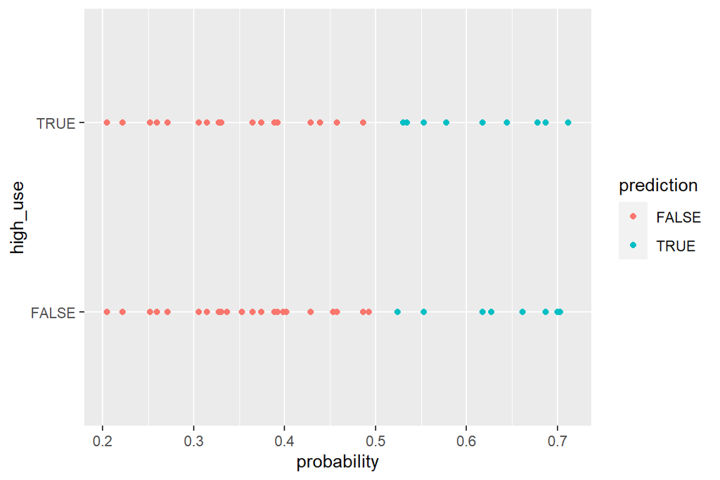

```r
ggplot(pormath_s, aes(probability, high_use, col=prediction)) +
  geom_point()
```

```r
table(high_use = pormath_s$high_use, prediction = pormath_s$prediction) %>% prop.table %>% addmargins
```

```
##         prediction
## high_use      FALSE       TRUE        Sum
##    FALSE 0.67027027 0.02972973 0.70000000
##    TRUE  0.26756757 0.03243243 0.30000000
##    Sum   0.93783784 0.06216216 1.00000000
```

```r
loss_func <- function(class, prob) {
  n_wrong <- abs(class - prob) > 0.5
  mean(n_wrong)
}

# call loss_func to compute the average number of wrong predictions in the (training) data
loss_func(class = pormath_s$high_use, prob = pormath_s$probability)
```

```
## [1] 0.2972973
```

## Cross-Validating the model

The ten-fold cross-validation shows a close performance of the predictive power of this model in the training and test sets (about 31% wrong) compared to to testing it with the whole data (30 % wrong).

```r
loss_func(class = pormath_s$high_use, prob = pormath_s$probability)
```

```
## [1] 0.2972973
```

```r
cv <- boot::cv.glm(data = pormath_s, cost = loss_func, glmfit = m1, K = 10)

cv$delta
```

```
## [1] 0.3027027 0.3013514
```

## Trying to find a better model for predictive power

Here I compare two different models to the M1 tested above. Before evaluating predictive power further, I examine these models by BIC change and R^2 -change. We find the third model below being the best of the three according to BIC and R^2 measures.

```r
jtools::summ(m1)
```

```
## MODEL INFO:
## Observations: 370
## Dependent Variable: high_use
## Type: Generalized linear model
##   Family: binomial
##   Link function: logit
##
## MODEL FIT:
## χ²(4) = 18.16, p = 0.00
## Pseudo-R² (Cragg-Uhler) = 0.07
## Pseudo-R² (McFadden) = 0.04
## AIC = 443.88, BIC = 463.45
##
## Standard errors: MLE
## ------------------------------------------------
##                      Est.   S.E.   z val.      p
## ----------------- ------- ------ -------- ------
## (Intercept)          0.39   0.64     0.61   0.54
## PstatusT            -0.10   0.38    -0.27   0.79
## nurseryyes          -0.31   0.29    -1.08   0.28
## failures             0.65   0.20     3.29   0.00
## famrel              -0.27   0.12    -2.14   0.03
## ------------------------------------------------
```

```r
jtools::summ(glm(high_use ~ failures + sex + address + famrel + freetime + goout + internet, family="binomial", data=pormath)) #freetime and internet access not significant; removing them.
```

```
## MODEL INFO:
## Observations: 370
## Dependent Variable: high_use
## Type: Generalized linear model
##   Family: binomial
##   Link function: logit
##
## MODEL FIT:
## χ²(7) = 83.08, p = 0.00
## Pseudo-R² (Cragg-Uhler) = 0.29
## Pseudo-R² (McFadden) = 0.18
## AIC = 384.96, BIC = 416.27
##
## Standard errors: MLE
## ------------------------------------------------
##                      Est.   S.E.   z val.      p
## ----------------- ------- ------ -------- ------
## (Intercept)         -2.23   0.77    -2.89   0.00
## failures             0.45   0.23     1.99   0.05
## sexM                 0.89   0.26     3.38   0.00
## addressU            -0.70   0.32    -2.22   0.03
## famrel              -0.43   0.14    -3.00   0.00
## freetime             0.11   0.14     0.75   0.46
## goout                0.76   0.13     5.90   0.00
## internetyes          0.26   0.38     0.69   0.49
## ------------------------------------------------
```

```r
jtools::summ(glm(high_use ~ failures + sex + address + famrel  + goout + absences, family="binomial", data=pormath))
```

```
## MODEL INFO:
## Observations: 370
## Dependent Variable: high_use
## Type: Generalized linear model
##   Family: binomial
##   Link function: logit
##
## MODEL FIT:
## χ²(6) = 94.64, p = 0.00
## Pseudo-R² (Cragg-Uhler) = 0.32
## Pseudo-R² (McFadden) = 0.21
## AIC = 371.39, BIC = 398.79
##
## Standard errors: MLE
## ------------------------------------------------
##                      Est.   S.E.   z val.      p
## ----------------- ------- ------ -------- ------
## (Intercept)         -2.27   0.71    -3.22   0.00
## failures             0.40   0.23     1.73   0.08
## sexM                 1.03   0.27     3.82   0.00
## addressU            -0.65   0.31    -2.07   0.04
## famrel              -0.40   0.15    -2.79   0.01
## goout                0.76   0.13     6.02   0.00
## absences             0.08   0.02     3.54   0.00
## ------------------------------------------------
```

```r
m3 <- glm(high_use ~ failures + sex + address + famrel  + goout + absences, family="binomial", data=pormath)
exp(cbind(OR = coef(m3), confint(m3)))
```

```
##                    OR     2.5 %    97.5 %
## (Intercept) 0.1030586 0.0248787 0.4001095
## failures    1.4913178 0.9538249 2.3728914
## sexM        2.7874285 1.6580283 4.7602275
## addressU    0.5238851 0.2836255 0.9691226
## famrel      0.6672113 0.5004071 0.8856192
## goout       2.1448371 1.6844140 2.7725681
## absences    1.0816926 1.0365062 1.1324925
```

```r
# predict() the probability of high_use
probabilities3 <- predict(m3, type = "response")

# add the predicted probabilities
pormath <- mutate(pormath, probability = probabilities3)

# use the probabilities to make a prediction of high_use
pormath <- mutate(pormath, prediction = probability > 0.5)


# tabulate the target variable versus the predictions
table(high_use = pormath$high_use, prediction = pormath_s$prediction)
```

```
##         prediction
## high_use FALSE TRUE
##    FALSE   248   11
##    TRUE     99   12
```

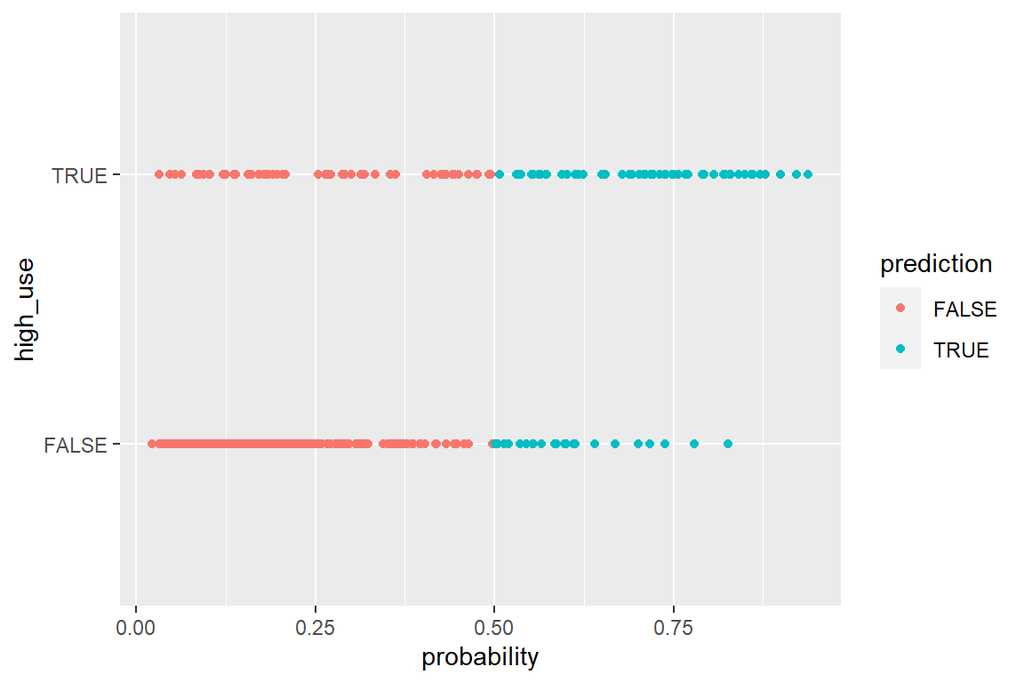

```r
ggplot(pormath, aes(probability, high_use, col=prediction)) +
  geom_point()
```

```r
table(high_use = pormath$high_use, prediction = pormath$prediction) %>% prop.table %>% addmargins
```

```
##         prediction
## high_use      FALSE       TRUE        Sum
##    FALSE 0.64054054 0.05945946 0.70000000
##    TRUE  0.15135135 0.14864865 0.30000000
##    Sum   0.79189189 0.20810811 1.00000000
```

```r
loss_func1 <- function(class, prob) {
  n_wrong <- abs(class - prob) > 0.5
  mean(n_wrong)
}

# call loss_func to compute the average number of wrong predictions in the (training) data
loss_func1(class = pormath$high_use, prob = pormath$probability)
```

```
## [1] 0.2108108
```

```r
#cross-validate
cv2 <- boot::cv.glm(data = pormath, cost = loss_func, glmfit = m3, K = 10)
#print error-rate of cross-validation
cv2$delta
```

```
## [1] 0.2081081 0.2132432
```

# Exercise 4

In this exercise the data used is the Boston dataset included in the MASS package. It comprises of 506 observations of 14 variables. The original rationale of the data was to predict housing prices by the NOx-levels by the area (see Harrison & Rubinfield, 1978). The 506 observations are of census tracts, and not districts as I supposed by the structure of the data. Details of the variables can be found [here](https://stat.ethz.ch/R-manual/R-devel/library/MASS/html/Boston.html)

Further, the rationale of this exercise is to find appropriate number of clusters.

Below you find the summary of the variables, overview of the data and density plots of the variables and finally the correlation plot of the data.

```r
library(tidyverse)
library(corrplot)
library(MASS)
library(viridis)
library(GGally)
data("Boston")

str(Boston)
```

```
## 'data.frame':    506 obs. of  14 variables:
##  $ crim   : num  0.00632 0.02731 0.02729 0.03237 0.06905 ...
##  $ zn     : num  18 0 0 0 0 0 12.5 12.5 12.5 12.5 ...
##  $ indus  : num  2.31 7.07 7.07 2.18 2.18 2.18 7.87 7.87 7.87 7.87 ...
##  $ chas   : int  0 0 0 0 0 0 0 0 0 0 ...
##  $ nox    : num  0.538 0.469 0.469 0.458 0.458 0.458 0.524 0.524 0.524 0.524 ...
##  $ rm     : num  6.58 6.42 7.18 7 7.15 ...
##  $ age    : num  65.2 78.9 61.1 45.8 54.2 58.7 66.6 96.1 100 85.9 ...
##  $ dis    : num  4.09 4.97 4.97 6.06 6.06 ...
##  $ rad    : int  1 2 2 3 3 3 5 5 5 5 ...
##  $ tax    : num  296 242 242 222 222 222 311 311 311 311 ...
##  $ ptratio: num  15.3 17.8 17.8 18.7 18.7 18.7 15.2 15.2 15.2 15.2 ...
##  $ black  : num  397 397 393 395 397 ...
##  $ lstat  : num  4.98 9.14 4.03 2.94 5.33 ...
##  $ medv   : num  24 21.6 34.7 33.4 36.2 28.7 22.9 27.1 16.5 18.9 ...
```

```r
summary(Boston)
```

```
##       crim                zn             indus            chas
##  Min.   : 0.00632   Min.   :  0.00   Min.   : 0.46   Min.   :0.00000
##  1st Qu.: 0.08205   1st Qu.:  0.00   1st Qu.: 5.19   1st Qu.:0.00000
##  Median : 0.25651   Median :  0.00   Median : 9.69   Median :0.00000
##  Mean   : 3.61352   Mean   : 11.36   Mean   :11.14   Mean   :0.06917
##  3rd Qu.: 3.67708   3rd Qu.: 12.50   3rd Qu.:18.10   3rd Qu.:0.00000
##  Max.   :88.97620   Max.   :100.00   Max.   :27.74   Max.   :1.00000
##       nox               rm             age              dis
##  Min.   :0.3850   Min.   :3.561   Min.   :  2.90   Min.   : 1.130
##  1st Qu.:0.4490   1st Qu.:5.886   1st Qu.: 45.02   1st Qu.: 2.100
##  Median :0.5380   Median :6.208   Median : 77.50   Median : 3.207
##  Mean   :0.5547   Mean   :6.285   Mean   : 68.57   Mean   : 3.795
##  3rd Qu.:0.6240   3rd Qu.:6.623   3rd Qu.: 94.08   3rd Qu.: 5.188
##  Max.   :0.8710   Max.   :8.780   Max.   :100.00   Max.   :12.127
##       rad              tax           ptratio          black
##  Min.   : 1.000   Min.   :187.0   Min.   :12.60   Min.   :  0.32
##  1st Qu.: 4.000   1st Qu.:279.0   1st Qu.:17.40   1st Qu.:375.38
##  Median : 5.000   Median :330.0   Median :19.05   Median :391.44
##  Mean   : 9.549   Mean   :408.2   Mean   :18.46   Mean   :356.67
##  3rd Qu.:24.000   3rd Qu.:666.0   3rd Qu.:20.20   3rd Qu.:396.23
##  Max.   :24.000   Max.   :711.0   Max.   :22.00   Max.   :396.90
##      lstat            medv
##  Min.   : 1.73   Min.   : 5.00
##  1st Qu.: 6.95   1st Qu.:17.02
##  Median :11.36   Median :21.20
##  Mean   :12.65   Mean   :22.53
##  3rd Qu.:16.95   3rd Qu.:25.00
##  Max.   :37.97   Max.   :50.00
```

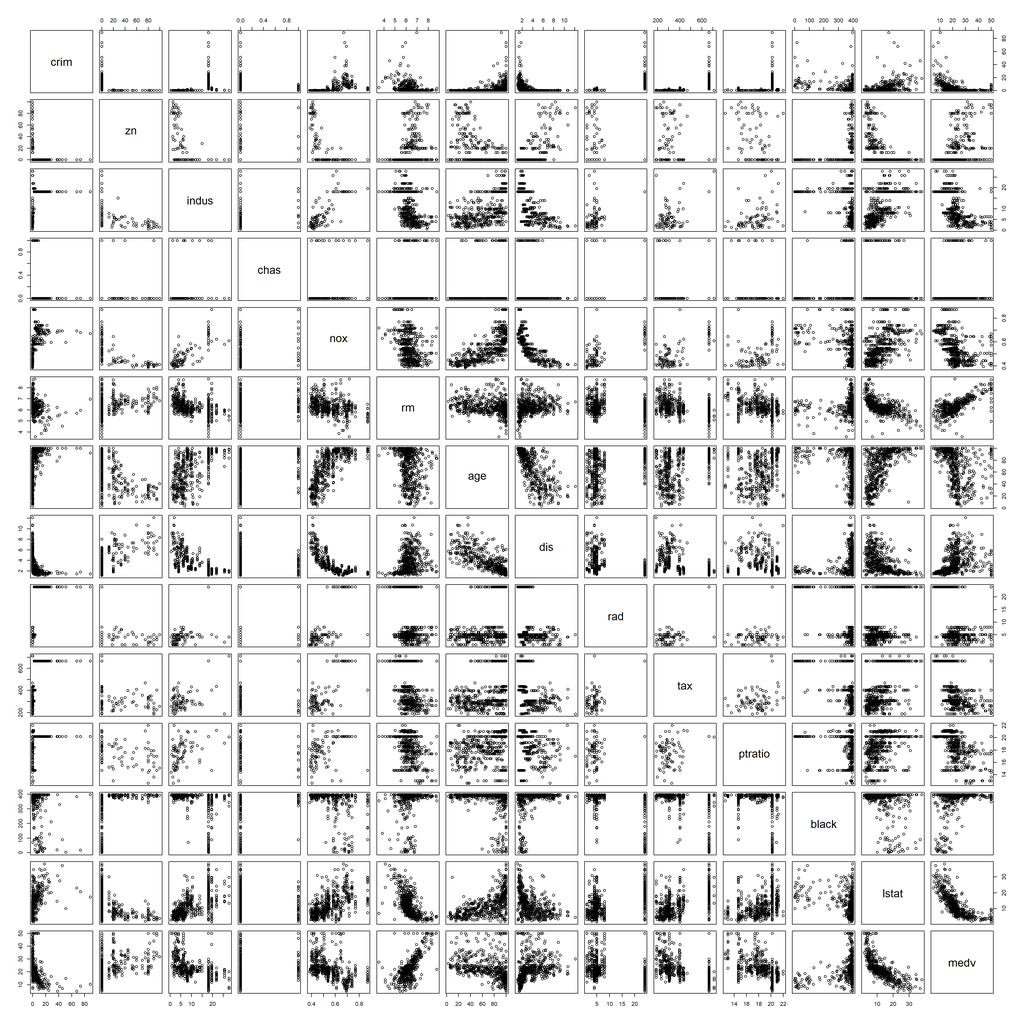

```r
pairs(Boston)
```

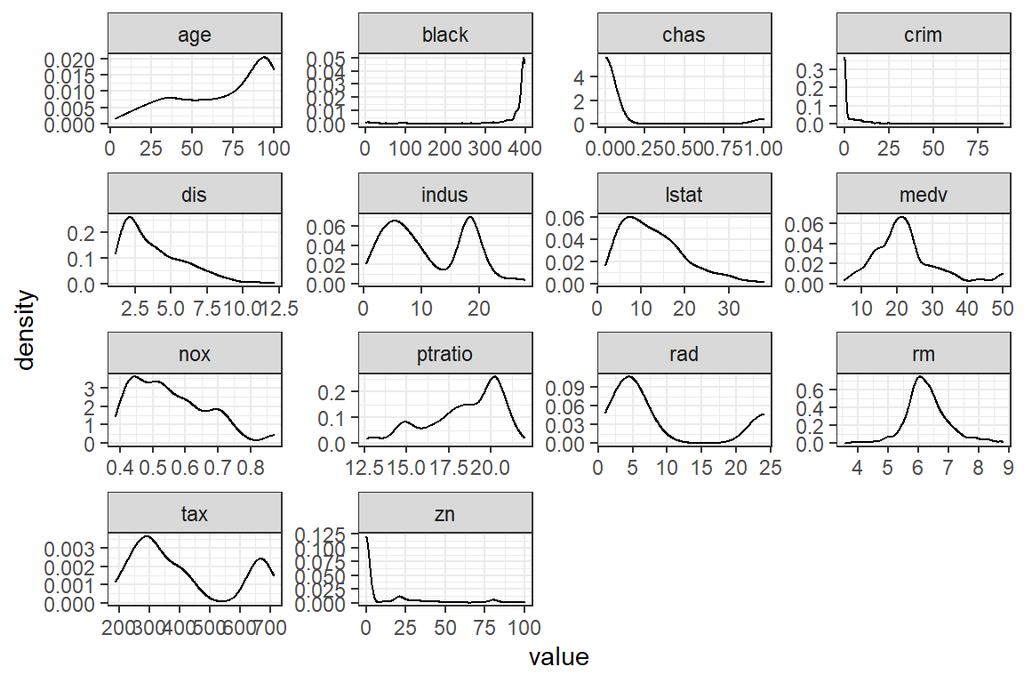

```r
Boston %>%
  gather(key=var_name, value = value) %>%
  ggplot(aes(x=value)) +
  geom_density() +
  facet_wrap(~var_name, scales="free") + theme_bw()
```

```r
cor_matrix <- cor(Boston) %>% round(digits = 2)
cor_matrix
```

```
##          crim    zn indus  chas   nox    rm   age   dis   rad   tax ptratio
## crim     1.00 -0.20  0.41 -0.06  0.42 -0.22  0.35 -0.38  0.63  0.58    0.29
## zn      -0.20  1.00 -0.53 -0.04 -0.52  0.31 -0.57  0.66 -0.31 -0.31   -0.39
## indus    0.41 -0.53  1.00  0.06  0.76 -0.39  0.64 -0.71  0.60  0.72    0.38
## chas    -0.06 -0.04  0.06  1.00  0.09  0.09  0.09 -0.10 -0.01 -0.04   -0.12
## nox      0.42 -0.52  0.76  0.09  1.00 -0.30  0.73 -0.77  0.61  0.67    0.19
## rm      -0.22  0.31 -0.39  0.09 -0.30  1.00 -0.24  0.21 -0.21 -0.29   -0.36
## age      0.35 -0.57  0.64  0.09  0.73 -0.24  1.00 -0.75  0.46  0.51    0.26
## dis     -0.38  0.66 -0.71 -0.10 -0.77  0.21 -0.75  1.00 -0.49 -0.53   -0.23
## rad      0.63 -0.31  0.60 -0.01  0.61 -0.21  0.46 -0.49  1.00  0.91    0.46
## tax      0.58 -0.31  0.72 -0.04  0.67 -0.29  0.51 -0.53  0.91  1.00    0.46
## ptratio  0.29 -0.39  0.38 -0.12  0.19 -0.36  0.26 -0.23  0.46  0.46    1.00
## black   -0.39  0.18 -0.36  0.05 -0.38  0.13 -0.27  0.29 -0.44 -0.44   -0.18
## lstat    0.46 -0.41  0.60 -0.05  0.59 -0.61  0.60 -0.50  0.49  0.54    0.37
## medv    -0.39  0.36 -0.48  0.18 -0.43  0.70 -0.38  0.25 -0.38 -0.47   -0.51
##         black lstat  medv
## crim    -0.39  0.46 -0.39
## zn       0.18 -0.41  0.36
## indus   -0.36  0.60 -0.48
## chas     0.05 -0.05  0.18
## nox     -0.38  0.59 -0.43
## rm       0.13 -0.61  0.70
## age     -0.27  0.60 -0.38
## dis      0.29 -0.50  0.25
## rad     -0.44  0.49 -0.38
## tax     -0.44  0.54 -0.47
## ptratio -0.18  0.37 -0.51
## black    1.00 -0.37  0.33
## lstat   -0.37  1.00 -0.74
## medv     0.33 -0.74  1.00
```

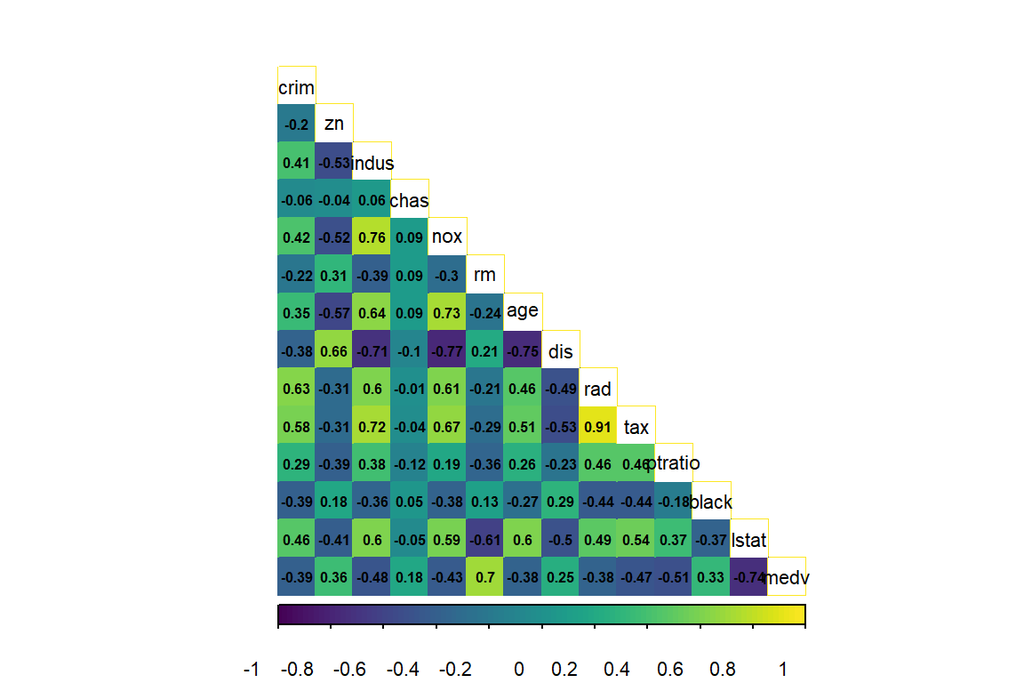

```r
corrplot(cor_matrix, method="color", type = "lower", cl.pos="b", tl.pos="d", tl.cex=0.7, cl.cex = 0.7, col = viridis(n=100), tl.col = "black" ,addCoef.col=T, number.cex=0.5)
```

First, the data will be scaled (x - mean(x)) / sd(x)). Then we create a categorical variable of the crime-variable with quantiles as break points. Then we remove the old crim variable, and add the categorised crime variable into the dataframe instead.

```r
boston_scaled <- scale(Boston)

boston_scaled <- as.data.frame(boston_scaled)

summary(boston_scaled)
```

```
##       crim                 zn               indus              chas
##  Min.   :-0.419367   Min.   :-0.48724   Min.   :-1.5563   Min.   :-0.2723
##  1st Qu.:-0.410563   1st Qu.:-0.48724   1st Qu.:-0.8668   1st Qu.:-0.2723
##  Median :-0.390280   Median :-0.48724   Median :-0.2109   Median :-0.2723
##  Mean   : 0.000000   Mean   : 0.00000   Mean   : 0.0000   Mean   : 0.0000
##  3rd Qu.: 0.007389   3rd Qu.: 0.04872   3rd Qu.: 1.0150   3rd Qu.:-0.2723
##  Max.   : 9.924110   Max.   : 3.80047   Max.   : 2.4202   Max.   : 3.6648
##       nox                rm               age               dis
##  Min.   :-1.4644   Min.   :-3.8764   Min.   :-2.3331   Min.   :-1.2658
##  1st Qu.:-0.9121   1st Qu.:-0.5681   1st Qu.:-0.8366   1st Qu.:-0.8049
##  Median :-0.1441   Median :-0.1084   Median : 0.3171   Median :-0.2790
##  Mean   : 0.0000   Mean   : 0.0000   Mean   : 0.0000   Mean   : 0.0000
##  3rd Qu.: 0.5981   3rd Qu.: 0.4823   3rd Qu.: 0.9059   3rd Qu.: 0.6617
##  Max.   : 2.7296   Max.   : 3.5515   Max.   : 1.1164   Max.   : 3.9566
##       rad               tax             ptratio            black
##  Min.   :-0.9819   Min.   :-1.3127   Min.   :-2.7047   Min.   :-3.9033
##  1st Qu.:-0.6373   1st Qu.:-0.7668   1st Qu.:-0.4876   1st Qu.: 0.2049
##  Median :-0.5225   Median :-0.4642   Median : 0.2746   Median : 0.3808
##  Mean   : 0.0000   Mean   : 0.0000   Mean   : 0.0000   Mean   : 0.0000
##  3rd Qu.: 1.6596   3rd Qu.: 1.5294   3rd Qu.: 0.8058   3rd Qu.: 0.4332
##  Max.   : 1.6596   Max.   : 1.7964   Max.   : 1.6372   Max.   : 0.4406
##      lstat              medv
##  Min.   :-1.5296   Min.   :-1.9063
##  1st Qu.:-0.7986   1st Qu.:-0.5989
##  Median :-0.1811   Median :-0.1449
##  Mean   : 0.0000   Mean   : 0.0000
##  3rd Qu.: 0.6024   3rd Qu.: 0.2683
##  Max.   : 3.5453   Max.   : 2.9865
```

```r
bins <- quantile(boston_scaled$crim)
crime <- cut(boston_scaled$crim, breaks=bins, include.lowest=T, label=c("low", "med_low", "med_high", "high"))
table(crime)
```

```
## crime
##      low  med_low med_high     high
##      127      126      126      127
```

```r
boston_scaled <- dplyr::select(boston_scaled, -crim)
boston_scaled <- data.frame(boston_scaled, crime)
```

Next the data will be divided to train and test sets.

```r
n <- 506
ind <- sample(n, size = n * 0.8)
train <- boston_scaled[ind,]
test<-boston_scaled[-ind,]
correct_classes <- test$crime
test <- dplyr::select(test, -crime)
```

```r
# MASS and train are available

# linear discriminant analysis
lda.fit <- lda(crime ~., data = train)

# print the lda.fit object
lda.fit
```

```
## Call:
## lda(crime ~ ., data = train)
##
## Prior probabilities of groups:
##       low   med_low  med_high      high
## 0.2475248 0.2376238 0.2698020 0.2450495
##
## Group means:
##                   zn      indus        chas        nox          rm        age
## low       1.07627459 -0.9272670 -0.11484506 -0.9003983  0.43922300 -0.9703732
## med_low  -0.05690559 -0.3310246 -0.06727176 -0.5758430 -0.06742501 -0.4092419
## med_high -0.39125834  0.2307918  0.23335353  0.4329335 -0.01106150  0.4200590
## high     -0.48724019  1.0171737 -0.03371693  1.0307098 -0.41959723  0.8141007
##                 dis        rad        tax     ptratio      black       lstat
## low       0.9628720 -0.7073876 -0.7017870 -0.44136612  0.3750898 -0.79340631
## med_low   0.3668121 -0.5404292 -0.4281801 -0.08338944  0.3140069 -0.23303327
## med_high -0.3720358 -0.4266032 -0.2962813 -0.22227888  0.0918840  0.08325813
## high     -0.8652938  1.6375616  1.5136504  0.78011702 -0.7524646  0.84246980
##                 medv
## low       0.52986175
## med_low   0.03958514
## med_high  0.09349184
## high     -0.60806121
##
## Coefficients of linear discriminants:
##                  LD1         LD2         LD3
## zn       0.106992284  0.65362683 -1.06467417
## indus    0.001661825 -0.33450886  0.18299341
## chas    -0.086870422 -0.05672059  0.02318201
## nox      0.331351996 -0.68427720 -1.32287518
## rm      -0.103289513 -0.06933531 -0.12955146
## age      0.327332269 -0.35125843 -0.18098238
## dis     -0.090421728 -0.30458073  0.09380892
## rad      3.288035760  0.71603137 -0.13510803
## tax     -0.095326845  0.31040312  0.75125295
## ptratio  0.154515281 -0.01114446 -0.41300356
## black   -0.108934358 -0.01270502  0.12122587
## lstat    0.260711232 -0.28741827  0.15317597
## medv     0.235942691 -0.36802358 -0.28228003
##
## Proportion of trace:
##    LD1    LD2    LD3
## 0.9460 0.0423 0.0116
```

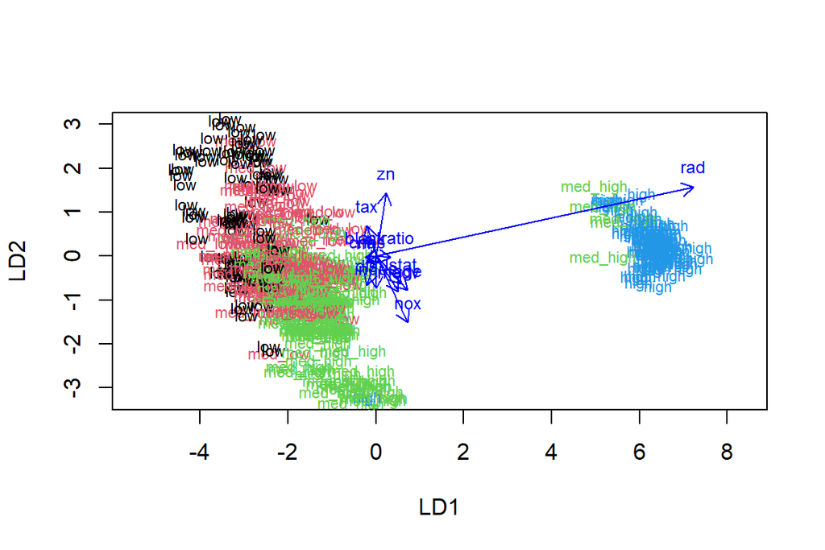

```r
# the function for lda biplot arrows
lda.arrows <- function(x, myscale = 1, arrow_heads = 0.1, color = "blue", tex = 0.75, choices = c(1,2)){
  heads <- coef(x)
  arrows(x0 = 0, y0 = 0,
         x1 = myscale * heads[,choices[1]],
         y1 = myscale * heads[,choices[2]], col=color, length = arrow_heads)
  text(myscale * heads[,choices], labels = row.names(heads),
       cex = tex, col=color, pos=3)
}

# target classes as numeric
classes <- as.numeric(train$crime)

# plot the lda results
plot(lda.fit, dimen = 2, col = classes, pch = classes)
lda.arrows(lda.fit, myscale = 2.2)
```

```r
lda.pred <- predict(lda.fit, newdata = test)
table(correct = correct_classes, predicted = lda.pred$class)
```

```
##           predicted
## correct    low med_low med_high high
##   low       10      14        3    0
##   med_low    1      19       10    0
##   med_high   0       2       14    1
##   high       0       0        0   28
```

Next I re-run and scale the Boston data set and calculate distances between the observations.

```r
data("Boston")

boston_scaled_k <- scale(Boston)

boston_scaled_k <- as.data.frame(boston_scaled_k)

summary(dist(boston_scaled_k))
```

```
##    Min. 1st Qu.  Median    Mean 3rd Qu.    Max.
##  0.1343  3.4625  4.8241  4.9111  6.1863 14.3970
```

Next the data will be clustered with K-means. The largest drop in the plot appears at two (2) clusters. Therefore, a two-cluster solution test follows.

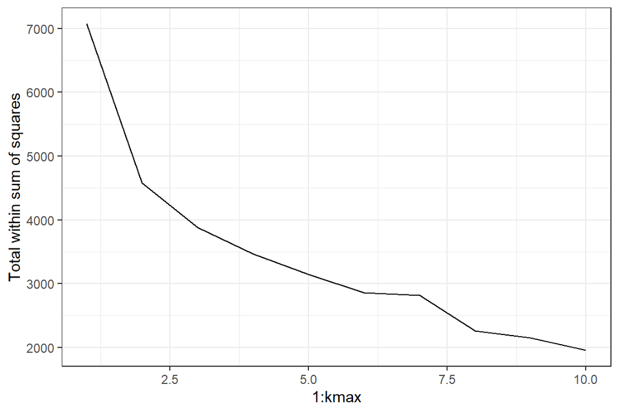

```r
kmax <- 10
set.seed(123)
totws <- sapply(1:kmax, function(k){kmeans(boston_scaled_k, k)$tot.withinss})
qplot(x = 1:kmax, y=totws, geom='line') + theme_bw() +
  ylab("Total within sum of squares")
```

A two cluster solution is plotted below. As anticipated from the density plots before, it looks like that the same variables correspond to the two cluster solution that were eminent from the density-plots. Non-retail business acres per town (indus) and property-tax rate (tax) can be seen very clearly. Also NOx levels seem to be nicely clustered to different clusters. The density plots are shown here aswell for a scroll-free comparison.

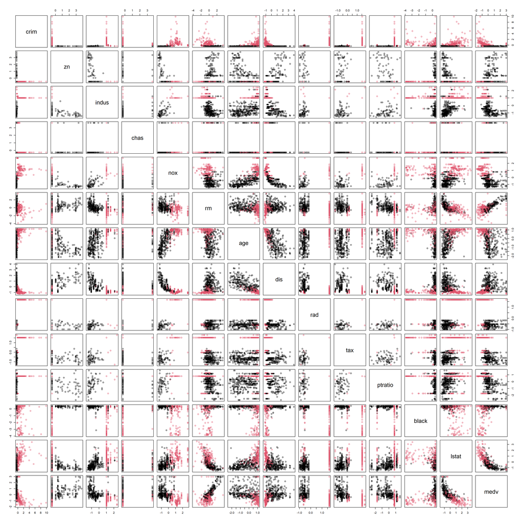

```r
kme <- kmeans(boston_scaled_k, centers = 2)
pairs(boston_scaled_k, col=kme$cluster)
```

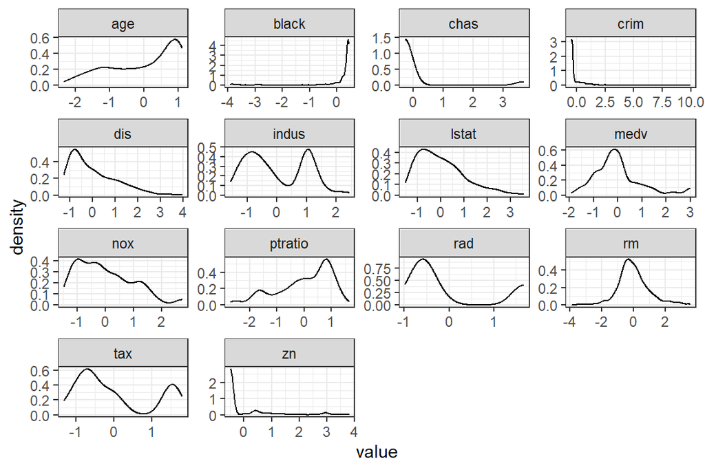

```r
boston_scaled_k %>%
  gather(key=var_name, value = value) %>%
  ggplot(aes(x=value)) +
  geom_density() +
  facet_wrap(~var_name, scales="free") + theme_bw()
```